Let’s take a look at individual competitors in the academic UIL competitions.

## Individual Participation

The first question that comes to mind is that of participation–which individuals have competed the most?

**NOTE:** *To give some context to the values for individual participants, I’ll include the numbers for myself (“Elhabr, Anthony”) in applicable contexts.*

| rnk | name | school | conf | n |
| --- | --- | --- | --- | --- |
| 1 | Jansa, Wade | GARDEN CITY | 1 | 57 |
| 2 | Chen, Kevin | CLEMENTS | 5 | 56 |
| 3 | Hanson, Dillon | LINDSAY | 1 | 53 |
| 4 | Gee, John | CALHOUN | 4 | 47 |
| 5 | Zhang, Mark | CLEMENTS | 5 | 47 |
| 6 | Robertson, Nick | BRIDGE CITY | 3 | 46 |
| 7 | Ryan, Alex | KLEIN | 5 | 46 |
| 8 | Strelke, Nick | ARGYLE | 3 | 45 |
| 9 | Niehues, Taylor | GARDEN CITY | 1 | 44 |
| 10 | Bass, Michael | SPRING HILL | 3 | 43 |
| 11 | Xu, Steven | DAWSON | 4 | 43 |
| 12 | Pabillano, Anthony | FLOUR BLUFF | 4 | 42 |
| 13 | Stocks, Dane | KNIPPA | 1 | 42 |
| 14 | Lu, Tracy | CALHOUN | 4 | 41 |
| 15 | Schwartz, Colton | GARDEN CITY | 1 | 41 |
| 16 | Hermes, Colton | LINDSAY | 1 | 40 |
| 17 | Rudy, John | SAVOY | 1 | 40 |
| 18 | Runnels, Wesley | SCIENCE-ENG MAGNET | 5 | 40 |
| 19 | Coker, Ross | ARGYLE | 3 | 39 |
| 20 | Williams, Tyler | POOLVILLE | 1 | 39 |
| 1725 | Elhabr, Anthony | CLEMENS | 4 | 13 |

Although the names here may not provide much insight, the counts provide some context regarding the limits of individual participation.

Given that counts of overall participation may not be indicative of anything directly, it may be a better idea to break them down by conference.

| rnk | conf | n |
| --- | --- | --- |
| 1 | 5 | 27,733 |
| 2 | 1 | 23,754 |
| 3 | 4 | 22,186 |
| 4 | 2 | 22,086 |
| 5 | 3 | 20,563 |
| 6 | 6 | 7,015 |

It seems that there are not as many individual competitors in the 6A conference (`conf 6`). This seems to be true even when stratifying the individuals into groups of ranks (by count of individual participation).

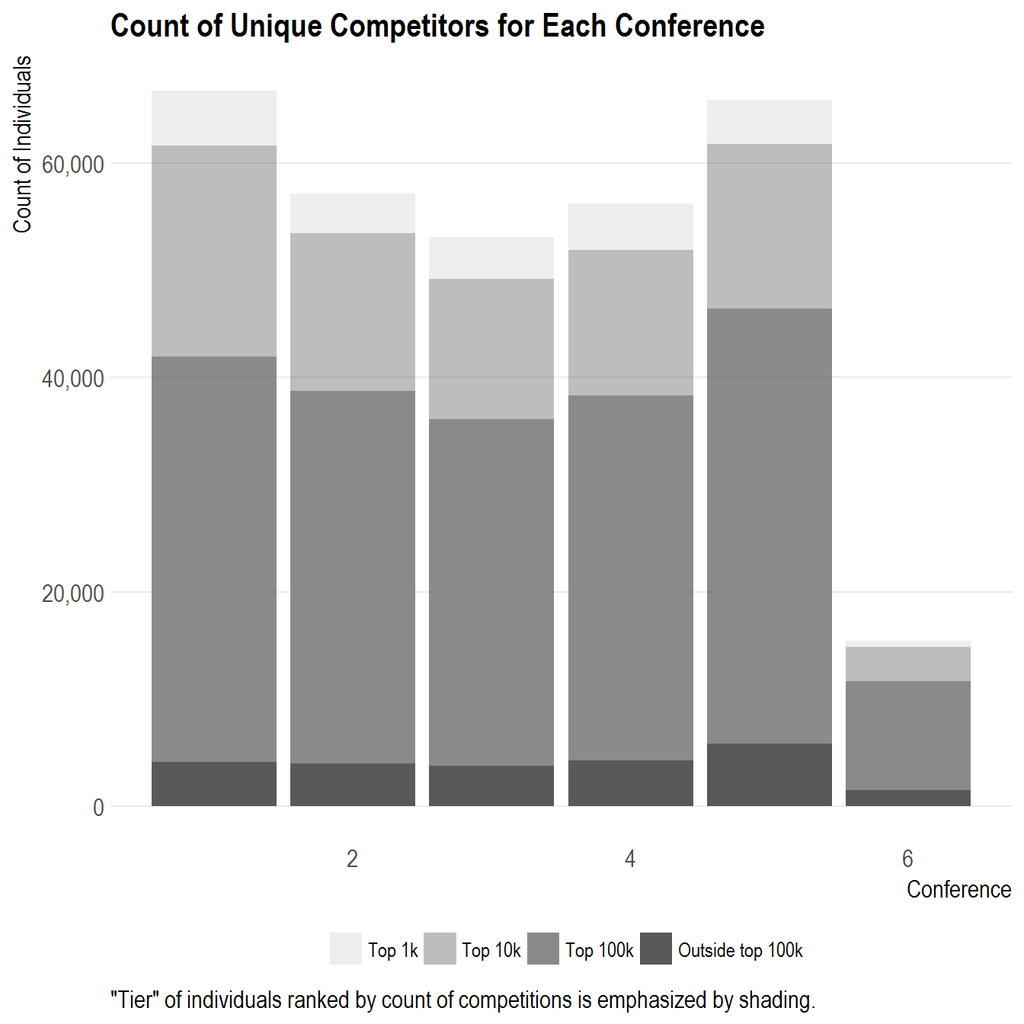

I hypothesize that the noticeable lack of individual competitors in conference 6A– which is the conference with largest high schools (according to student body size)– can be attributed to an intentional “allocation of talent” by these schools. In other words, these schools may be more likely to designate their individual competitors to compete in only specific competitions. By comparison, schools in the other conferences may be more willing to let individual students compete in as many competition types as they desire, even if they have not prepared for them whatsoever.

Along these lines, note that there is a limit on the number of entrants per school in a given competition. This means that smaller schools are much less likely to have enough people to reach the per-school limit, so individuals at these schools are more likely to compete in as many competitions as they choose.

Such a phenomenon might be evident in lower scores (in aggregate) for conferences where participation by distinct individuals is greater. In fact, this is exactly what is observed. [^1]

So what about people’s scores? Who did best according to score? In order to simplify the data, let’s look at a couple of statistics based on score, aggregating across all scores for each individual. In particular, let’s look at the average and sum of placing percent rank (`prnk`) and of individual competitors “defeated” (`n_defeat`). [^2]

| rnk | name | school | city | n | prnk_sum | prnk_mean | n_defeat_sum | n_defeat_mean |
| --- | --- | --- | --- | --- | --- | --- | --- | --- |
| 1 | Hanson, Dillon | LINDSAY | LINDSAY | 53 | 51.23 | 0.97 | 1546 | 29.17 |
| 2 | Chen, Kevin | CLEMENTS | SUGAR LAND | 56 | 51.09 | 0.91 | 1669 | 29.80 |
| 3 | Jansa, Wade | GARDEN CITY | GARDEN CITY | 57 | 50.87 | 0.89 | 1702 | 29.86 |
| 4 | Niehues, Taylor | GARDEN CITY | GARDEN CITY | 44 | 42.44 | 0.96 | 1373 | 31.20 |
| 5 | Gee, John | CALHOUN | PORT LAVACA | 47 | 42.25 | 0.90 | 1185 | 25.21 |
| 6 | Zhang, Mark | CLEMENTS | SUGAR LAND | 47 | 41.97 | 0.89 | 1370 | 29.15 |
| 7 | Strelke, Nick | ARGYLE | ARGYLE | 45 | 41.68 | 0.93 | 1195 | 26.56 |
| 8 | Robertson, Nick | BRIDGE CITY | BRIDGE CITY | 46 | 40.60 | 0.88 | 1165 | 25.33 |
| 9 | Ryan, Alex | KLEIN | KLEIN | 46 | 39.56 | 0.86 | 1205 | 26.20 |
| 10 | Xu, Steven | DAWSON | PEARLAND | 43 | 37.89 | 0.88 | 1153 | 26.81 |
| 11 | Coker, Ross | ARGYLE | ARGYLE | 39 | 37.17 | 0.95 | 1035 | 26.54 |
| 12 | Stocks, Dane | KNIPPA | KNIPPA | 42 | 36.80 | 0.88 | 1225 | 29.17 |
| 13 | Runnels, Wesley | SCIENCE-ENG MAGNET | DALLAS | 40 | 36.22 | 0.91 | 969 | 24.23 |
| 14 | Urbina, Jacob | ELKHART | ELKHART | 44 | 36.21 | 0.82 | 1122 | 25.50 |
| 15 | Lu, Tracy | CALHOUN | PORT LAVACA | 41 | 35.90 | 0.88 | 1048 | 25.56 |
| 16 | Pabillano, Anthony | FLOUR BLUFF | CORPUS CHRISTI | 42 | 34.92 | 0.83 | 1035 | 24.64 |
| 17 | McDonough, Kirsten | WYLIE | ABILENE | 38 | 34.04 | 0.90 | 991 | 26.08 |
| 18 | Cook, Jordan | WHITE OAK | WHITE OAK | 37 | 33.91 | 0.92 | 1136 | 30.70 |
| 19 | Ganeshram, Shri | HIRSCHI | WICHITA FALLS | 38 | 33.20 | 0.87 | 891 | 23.45 |
| 20 | Neville, David | TAYLOR | KATY | 36 | 33.08 | 0.92 | 1202 | 33.39 |
| 2608 | Elhabr, Anthony | CLEMENS | SCHERTZ | 13 | 7.76 | 0.60 | 216 | 16.62 |

Also, I think it’s interesting to look at the distribution of counts for advancement and state competition appearances. The heavily right skewed distribution of values gives an indication of the difficulty of succeeding consistently.

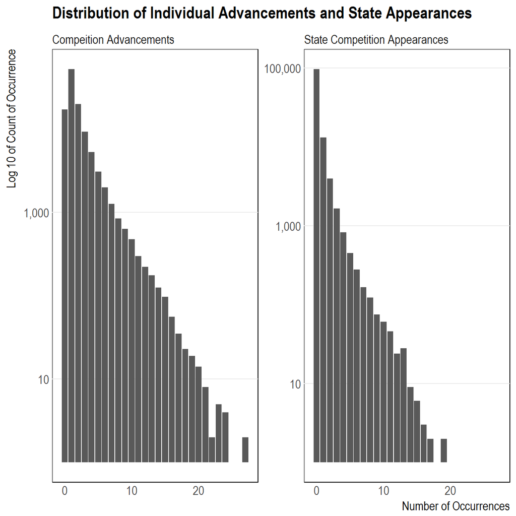

So it should be obvious that it is difficult to make it the highest level of competition–State. But exactly how difficult is it? Let’s identify those people (and their scores) who have made the State competition level four times–which is the upper limit for a typical high scool student [^3]– for a given competition type.

| name | school | city | conf | n |
| --- | --- | --- | --- | --- |
| Chen, Kevin | CLEMENTS | SUGAR LAND | 5 | 4 |
| Jansa, Wade | GARDEN CITY | GARDEN CITY | 1 | 4 |
| Hanson, Dillon | LINDSAY | LINDSAY | 1 | 3 |
| Strelke, Nick | ARGYLE | ARGYLE | 3 | 3 |
| Bass, Michael | SPRING HILL | LONGVIEW | 3 | 2 |
| Deaver, Matthew | SILSBEE | SILSBEE | 3 | 2 |
| Liu, Jason | DAWSON | PEARLAND | 4 | 2 |
| Ryan, Alex | KLEIN | KLEIN | 5 | 2 |
| Williams, Tyler | POOLVILLE | POOLVILLE | 1 | 2 |
| Xu, Steven | DAWSON | PEARLAND | 4 | 2 |
| Zhang, Mark | CLEMENTS | SUGAR LAND | 5 | 2 |

I would consider those individuals appearing here to be the “elite of the elite”.

## Individual Performance

Now, I want to try to answer a somewhat ambiguous question: Which individuals were most “dominant”?

### Evaluating “Dominance”

Because the term “dominance” is faily subjective, it must be defined explicilty. Here is my definition/methodology, along with some explanation.

First, I assign a percent rank to individual placings in all competitions based on score relative to other scores in that competition. I choose to use percent rank–which is a always a value between 0 and 1–because it inherently accounts for the wide range of number of competittors across all competitions. (For this context, a percent rank of 1 corresponds to the highest score in a given competition [^4], and, conversely, a value of 0 corresponds to the lowest score.)

I should note that I evaluated some other metrics for gauging individual success, including the total number of individuals defeated in competitions. Percent rank based on score and number of defeats attempt to quantify the same underlying variable, but I think percent rank is a little more “natural” to interpret because it contextualizes number of competitors with its unit range. By comparison, the interpretation of number of defeats is less direct because the number of other competitors is not accounted directly.

Then, to come up with a final set of ranks, one for each unique competitor, based on the percent ranks for individual competitions, I simply sum up the percent ranks for each individual.

The sum is used instead of an average [^5] because rankings based on averages –and inferences made upon them–are sensitive to individuals who do not compete in many competitions, yet place very well in them. A final ranking based on a summed value does not suffer from this pitfall, although it can be sensitive to the sample size of each participant. (i.e. An individual might partipate in a high number of competitions and under-perform relative to the average in all of them, yet their final ranking, based on summed percent ranks, might indicate that they are an above-average performer.)

| name | school | conf | rnk_sum_prnk | rnk_mean_prnk | rnk_sum_n_defeat | rnk_mean_n_defeat |
| --- | --- | --- | --- | --- | --- | --- |
| Hanson, Dillon | LINDSAY | 1 | 1 | 191 | 3 | 5205 |
| Chen, Kevin | CLEMENTS | 5 | 2 | 809 | 2 | 4834 |
| Jansa, Wade | GARDEN CITY | 1 | 3 | 1298 | 1 | 4827 |
| Niehues, Taylor | GARDEN CITY | 1 | 4 | 200 | 4 | 3612 |
| Gee, John | CALHOUN | 4 | 5 | 1114 | 14 | 10361 |
| Zhang, Mark | CLEMENTS | 5 | 6 | 1272 | 5 | 5213 |
| Strelke, Nick | ARGYLE | 3 | 7 | 562 | 12 | 8340 |
| Robertson, Nick | BRIDGE CITY | 3 | 8 | 1598 | 15 | 10277 |
| Ryan, Alex | KLEIN | 5 | 9 | 2561 | 8 | 8754 |
| Xu, Steven | DAWSON | 4 | 10 | 1661 | 16 | 8160 |
| Coker, Ross | ARGYLE | 3 | 11 | 279 | 21 | 8343 |
| Stocks, Dane | KNIPPA | 1 | 12 | 1830 | 7 | 5210 |
| Runnels, Wesley | SCIENCE-ENG MAGNET | 5 | 13 | 943 | 25 | 12130 |
| Lu, Tracy | CALHOUN | 4 | 14 | 1841 | 19 | 9912 |
| Pabillano, Anthony | FLOUR BLUFF | 4 | 15 | 4099 | 22 | 11577 |
| Ganeshram, Shri | HIRSCHI | 3 | 16 | 1946 | 42 | 13895 |
| Neville, David | TAYLOR | 5 | 17 | 689 | 9 | 2470 |
| Marchetti, Tommy | RUSK | 3 | 18 | 2574 | 24 | 8589 |
| Hermes, Colton | LINDSAY | 1 | 19 | 5862 | 23 | 9706 |
| Schwartz, Colton | GARDEN CITY | 1 | 20 | 7898 | 18 | 8128 |

<sup>1</sup> # of total rows: 123,337.0

Some of the same individuals from the participation-based ranking of competitors also appear among the top of the ranks by my evaluation of domination. This is somewhat expected due to the nature of my methodology (in particular, my choice to use a sum instead of an average or some other statistic). Certainly some additional statistical analysis could be done here to investigate other methods of quantifying dominance (beyond my analysis). [^6] Because there is no well-agreed upon metric or method anywhere for quantifying dominance for this particular topic, it’s difficult to really judge the findings here.

In any matter, the difference between the ranks based on the average and the sum of percent ranks is not all too great–I found that the correlation between the two is anywhere between ~0.75 and ~0.95 when using either score percent rank or number of defeats as the metric for ranking.

| rowname | rnk_sum_prnk | rnk_mean_prnk | rnk_sum_n_defeat | rnk_mean_n_defeat |
| --- | --- | --- | --- | --- |
| rnk_sum_prnk | NA | 0.82 | 0.95 | 0.74 |
| rnk_mean_prnk | 0.82 | NA | 0.78 | 0.88 |
| rnk_sum_n_defeat | 0.95 | 0.78 | NA | 0.84 |
| rnk_mean_n_defeat | 0.74 | 0.88 | 0.84 | NA |

### Evaluating “Carrying”

Another way of identifying superb ability is to compare the scores of individuals with those of their teammates. Individuals with high scores relative to their teammates might be said to have “carried” their teammates. Although this kind of evaluation is dependent on the skill of each team (independent of the competition setting), I think that it is another interesting way of evaluating skill.

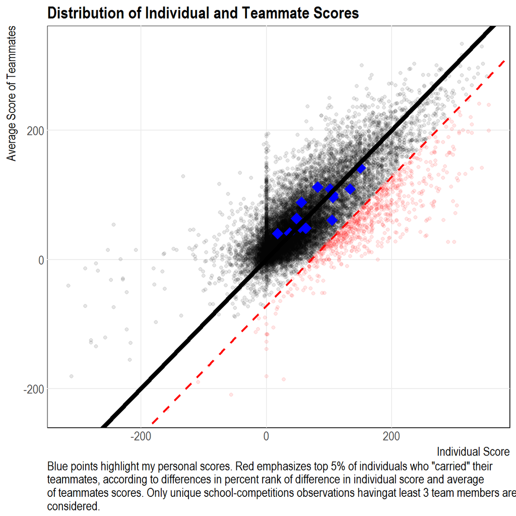

I was hoping that I might see myself appearing among the most dominant by this measure of skill, but it does not say anything necessarily bad about myself that I don’t. I competed with other individuals who I considered to be very knowledgeable and who often scored better than me. Also, from the opposite point of view, I don’t think I was a poor performer who relied upon teammates to boost the team’s overall score. This is why the data points corresponding to me show up in the middle of the pack in the previous visual.

### “Improvement”

I think something else that would be interesting to look at is personal “improvement” between years. Theoretically, if we assume that individuals improve their academic ability and competition skills every year, then we should see individual scores for a given competition type and level increase from one year to next. I would be very suprised to find that this is not true.

To evaluate improvement, we can simply reduce the whole data set to just those who have competed in the same competition type and level in more than one year and check whether or not their scores increased or decreased from one year to the next. [^7] Actually, in order to account for variance in competition difficulty across years, it’s better to use the percent rank of the individual’s placing (based on score) rather than score itself.

| improve | n |
| --- | --- |
| FALSE | 23,022 |
| TRUE | 35,305 |

So it is true that individual scores–actually, percent rank of placings–do tend to improve as the individual ages. But is this trend statistically significant? That’s easy enough to answer–we can simply perform a binomial test–where the null hypothesis is that the distribution of “TRUE” and “FALSE” regarding improvement is truly a 50 % - 50 % split. If the p.value of the test is below a thresshold value–let’s say 0.05–then we can deny the null hypothesis and say that there is a non-trivial trend of individual improvement.

| metric | value |
| --- | --- |
| estimate | 0.6053 |
| p.value | 0 |
| conf.low | 0.6013 |
| conf.high | 0.6093 |
| method | Exact binomial test |
| alternative | two.sided |

In fact, this is exactly what is observed.

Now, let’s reduce the set to just those who have appeared in competitions at a given competition type four times (for the sake of visualization) and plot the scores across years for each individual.

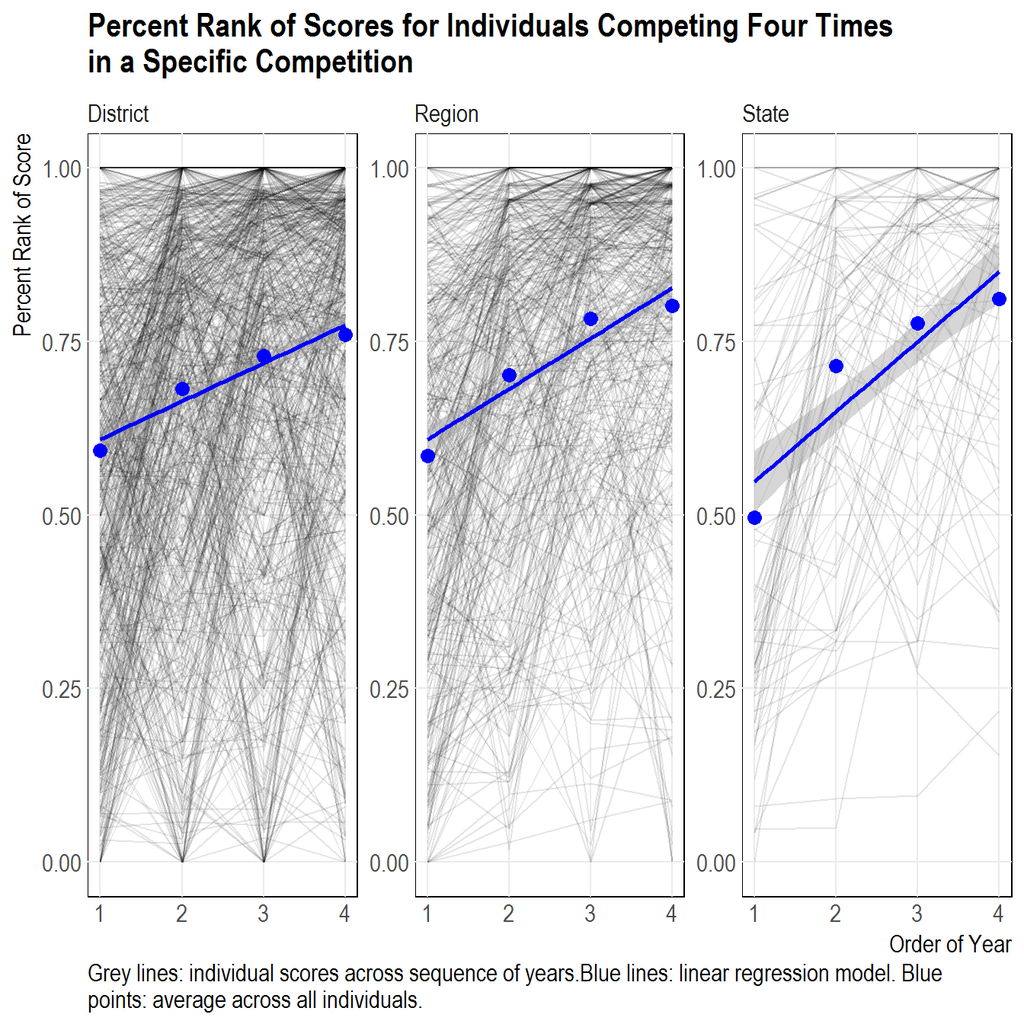

## Wrap-up

I’ll leave the discussion of individuals at that, although there is much more that could be explored.

[^1]: See a separate write-up for a visual illustrating this phenomenon.
[^2]: Competitors defeated is defined as the number of scores less that that of a given individual for a unique compeition, and a unique competition is defined as a unique combination of year, competition level, and competition type.
[^3]: The assuminption here is that each student takes four years to complete high school.
[^4]: A unique competition is defined as one having a unique year, competition type, and competition level.
[^5]: The average may also be considered a valid means of aggregating the values for each individual.
[^6]: I’ll leave furthere analysis for another person and/or time.
[^7]: I don’t think it is relevant to require that the scores be in consecutive years, so I don’t enforce that criteria.